# Regression_task_Laskina

NataliaLaskina

2025-01-16

## **Чтение данных**

```
##    SEQN DMDEDUC2 DMDHHSIZ DMDHHSZA DMDHHSZB DMDHHSZE DMDMARTL INDFMIN2 RIAGENDR
## 1 81603        4        1        0        0        1        2        4        2
## 2 81783        5        3        0        1        0        1       12        1
## 3 80825        3        5        0        2        0        1        7        1
## 4 74081        4        2        0        0        2        1        5        1
## 5 83352        3        6        0        1        1        5       12        1
## 6 79661        3        7        1        2        0        1       12        1
##   RIDAGEYR RIDRETH3 DR1TALCO DR1TCHOL DR1TFIBE DR1TKCAL DR1TMFAT DR1TPFAT
## 1       76        3      0.0      209     18.5     2455   29.935   14.370
## 2       44        4     51.4      236     10.1     2489   39.509   50.495
## 3       30        3      0.0      245     14.6     2681   22.827    9.629
## 4       80        3      0.0      615     20.0     3447   69.960   29.231
## 5       20        4      0.0      211     15.1     2549   27.744   29.045
## 6       52        6      0.0        5     16.7      538    5.360    2.401
##   DR1TSFAT DR1TSUGR DR1TTFAT DRD340 DRD360 DRQSDIET DRQSDT1 DRQSDT10 DRQSDT2
```

[output cut: 41 more lines]

```
## Rows: 916
## Columns: 74
## $ SEQN     <dbl> 81603, 81783, 80825, 74081, 83352, 79661, 77680, 77727, 77013…
## $ DMDEDUC2 <dbl> 4, 5, 3, 4, 3, 3, 4, 5, 5, 1, 5, 1, 3, 3, 2, 3, 4, 4, 5, 3, 1…
## $ DMDHHSIZ <dbl> 1, 3, 5, 2, 6, 7, 5, 5, 5, 5, 2, 2, 1, 2, 4, 5, 2, 1, 2, 4, 4…
## $ DMDHHSZA <dbl> 0, 0, 0, 0, 0, 1, 0, 1, 0, 0, 0, 0, 0, 0, 0, 0, 0, 0, 0, 0, 0…
## $ DMDHHSZB <dbl> 0, 1, 2, 0, 1, 2, 0, 0, 2, 2, 0, 0, 0, 0, 1, 1, 0, 0, 0, 0, 0…
## $ DMDHHSZE <dbl> 1, 0, 0, 2, 1, 0, 0, 2, 0, 1, 2, 1, 1, 0, 2, 0, 2, 0, 0, 0, 1…
## $ DMDMARTL <dbl> 2, 1, 1, 1, 5, 1, 5, 1, 5, 5, 1, 1, 3, 1, 1, 1, 1, 3, 1, 3, 1…
## $ INDFMIN2 <dbl> 4, 12, 7, 5, 12, 12, 12, 11, 12, 4, 4, 5, 4, 7, 8, 12, 9, 4, …
## $ RIAGENDR <dbl> 2, 1, 1, 1, 1, 1, 1, 2, 1, 2, 1, 2, 2, 1, 1, 2, 1, 1, 2, 1, 1…
## $ RIDAGEYR <dbl> 76, 44, 30, 80, 20, 52, 22, 45, 25, 62, 80, 56, 74, 43, 78, 4…
## $ RIDRETH3 <dbl> 3, 4, 3, 3, 4, 6, 7, 6, 3, 1, 3, 1, 4, 2, 1, 3, 1, 7, 4, 3, 1…
## $ DR1TALCO <dbl> 0.0, 51.4, 0.0, 0.0, 0.0, 0.0, 89.2, 0.0, 0.0, 0.0, 0.0, 0.0,…
## $ DR1TCHOL <dbl> 209, 236, 245, 615, 211, 5, 397, 186, 269, 311, 116, 64, 264,…
```

[output cut: 61 more lines]

## **Расчет показателя Физическая активность**

Физическая активность будет рассчитываться по показателю MET (Metabolic Equivalent of Task) - это физиологическая мера, выражающая энергозатраты на физическую активность. 1 MET равен потреблению кислорода в состоянии покоя. Это стандартизированная мера, широко используемая в исследованиях физической активности и общественного здоровья.

Формула расчета для каждого вида активности:

MET-минуты в неделю = (MET интенсивность) × (минуты активности) × (дни в неделю)

Рабочая активность: Высокая интенсивность (PAQ605, PAQ610, PAD615): 8 MET × минуты в день × дни в неделю

Умеренная интенсивность (PAQ620, PAQ625, PAD630): 4 MET × минуты в день × дни в неделю

Транспортная активность (PAQ635, PAQ640, PAD645): Ходьба/велосипед: 3.3 MET × минуты в день × дни в неделю

Рекреационная активность: Высокая интенсивность (PAQ650, PAQ655, PAD660): 8 MET × минуты в день × дни в неделю

Умеренная интенсивность (PAQ665, PAQ670, PAD675): 4 MET × минуты в день × дни в неделю

Общий показатель физической активности:

Общие MET-минуты = Сумма MET-минут всех видов активности

Категоризация общей физической активности:

Низкая: < 600 MET-минут в неделю Средняя: 600-1500 MET-минут в неделю Высокая: > 1500 MET-минут в неделю

Стандартные коэффициенты MET: 1 MET = потребление кислорода в состоянии покоя (≈3.5 мл O₂/кг/мин). Легкая активность: 1.1-2.9 ME. Умеренная активность: 3-5.9 MET (поэтому используется коэффициент 4). Интенсивная активность: ≥6 MET (поэтому используется коэффициент 8). Ходьба: 3.3 MET (стандартный коэффициент для обычной ходьбы). В руководстве GPAQ (Global Physical Activity Questionnaire) ВОЗ используются именно эти коэффициенты для расчета общей физической активности.

Предполагаем, что эффект физической активности в отношении гликированного гемоглобина будет выражаться в том, что при увеличении физической активности уровеннь гликированного гемоглобина будет снижаться..

```
##    Min. 1st Qu.  Median    Mean 3rd Qu.    Max.
##       0       0     936    2976    3395   33582
```

```
##
##  Низкая Средняя Высокая
##     403     138     375
```

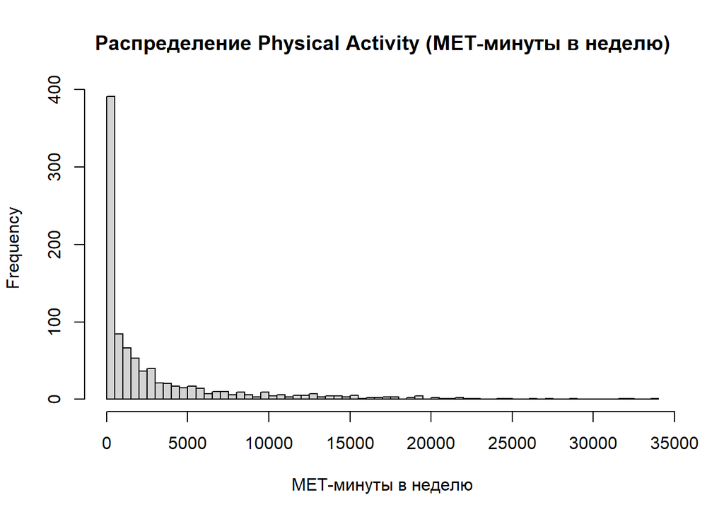

## **Ковариаты. Показатель Smoking**

Ковариаты, включенные в модель для коррекции эффекта физической активности в отношении гликированного гемоглобина, согласно ациклическому графу (DAG)1: Comorbidities,Race,Sex,Smoking. Информация о Race и Sex имеется напрямую в нашем датасете.

Для оценки Smoking: в датасете есть переменные SMQ020 - Smoked at least 100 cigarettes in life: yes or no, и SMQ040 - Do you now smoke cigarettes: Every day, Some days, Not at all. Из этих двух переменных можно создать более информативную категориальную переменную уровня курения, учитывающую как историю курения, так и текущий статус.

Создаем переменную Smoking_status с следующими категориями:

Never smoker (Никогда не курил) - SMQ020 = “No”; Current smoker (Текущий курильщик) - SMQ020 = “Yes” и SMQ040 = “Every day” или “Some days”; Former smoker (Бывший курильщик) - SMQ020 = “Yes” и SMQ040 = “Not at all”.

```
##
##   Never smoker  Former smoker Current smoker
##            488            264            164
```

## **Ковариаты. Показатель Comorbidities**

Показатель Comorbidities (Сопутствующие заболевания). Из предоставленных данных можно создать индекс коморбидности, учитывая следующие хронические заболевания:

Сердечно-сосудистые заболевания: MCQ160C - Coronary heart disease; MCQ160B - Congestive heart failure; MCQ160E - Heart attack; MCQ160F - Stroke; BPQ020 - Hypertension.

Респираторные заболевания: MCQ010 - Asthma (если MCQ035 = “Yes” - текущая астма); MCQ160O - COPD.

Эндокринные заболевания: MCQ160m - Thyroid problem (если MCQ170m = “Yes” - текущая проблема); DIQ010 - Diabetes.

Онкологические заболевания: MCQ220 - Cancer or malignancy.

Такой индекс можно использовать как количественную переменную (число заболеваний), так и как категориальную переменную (нет/одно/множественные заболевания).

Диабет намеренно не включаем, так как он тесно связан с уровнем гликированного гемоглобина (Hb1Ac). Будем учитывать только текущие случаи астмы и проблем с щитовидной железой.

```
##
##   0   1   2   3   4   5   6   7
## 386 310 140  47  19   9   4   1
```

```
##
##       No comorbidities        One comorbidity Multiple comorbidities
##                    386                    310                    220
```

## **Подготовка данных для модели**

```
## Rows: 916
## Columns: 7
## $ ID                            <dbl> 81603, 81783, 80825, 74081, 83352, 79661…
## $ `Glycated hemoglobin (HbA1c)` <dbl> 6.2, 5.6, 5.2, 5.8, 5.2, 5.3, 5.0, 6.4, …
## $ Physical_activity             <dbl> 1120.0, 6120.0, 14400.0, 4800.0, 9660.0,…
## $ Race                          <fct> Non-Hispanic White, Non-Hispanic Black, …
## $ Gender                        <fct> Female, Male, Male, Male, Male, Male, Ma…
## $ Smoking_status                <fct> Never smoker, Never smoker, Current smok…
## $ Comorbidities_cat             <fct> Multiple comorbidities, No comorbidities…
```

## **Описательная статистика**

| **Characteristic** | **N = 916** |
| --- | --- |
| Glycated hemoglobin (HbA1c) |  |
| Mean (SD) | 5.80 (1.04) |
| Median (Q1-Q3) | 5.60 (5.30-5.90) |
| Min-Max | 4.20-13.90 |
| Physical_activity |  |
| Mean (SD) | 2,976 (4,929) |
| Median (Q1-Q3) | 936 (0-3,399) |
| Min-Max | 0-33,582 |
| Race |  |
| Mexican American | 101 (11%) |
| Other Hispanic | 75 (8.2%) |
| Non-Hispanic White | 463 (51%) |
| Non-Hispanic Black | 175 (19%) |
| Non-Hispanic Asian | 78 (8.5%) |
| Other Race - Including Multi-Racial | 24 (2.6%) |
| Gender |  |
| Male | 539 (59%) |
| Female | 377 (41%) |
| Smoking_status |  |
| Never smoker | 488 (53%) |
| Former smoker | 264 (29%) |
| Current smoker | 164 (18%) |
| Comorbidities_cat |  |
| No comorbidities | 386 (42%) |
| One comorbidity | 310 (34%) |
| Multiple comorbidities | 220 (24%) |

## **Эксплораторный анализ (графики)**

### Количественные переменные

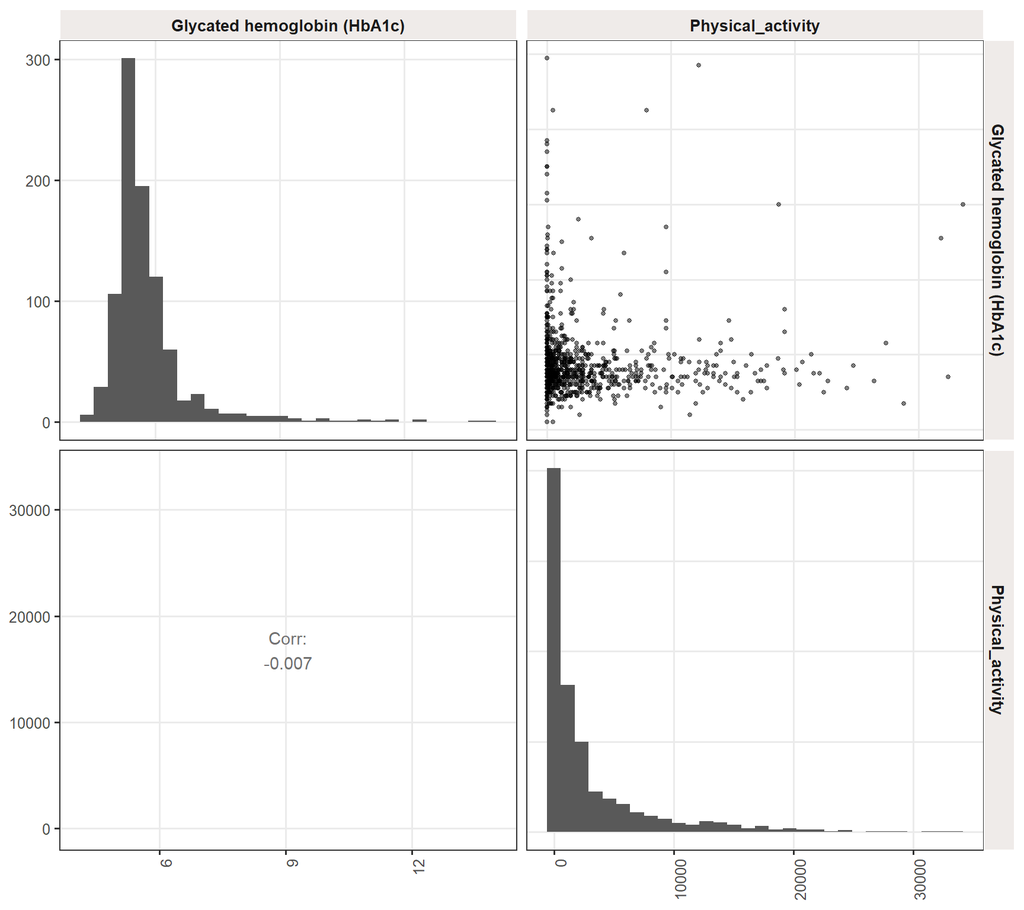

### Категориальные переменные

#### Gender

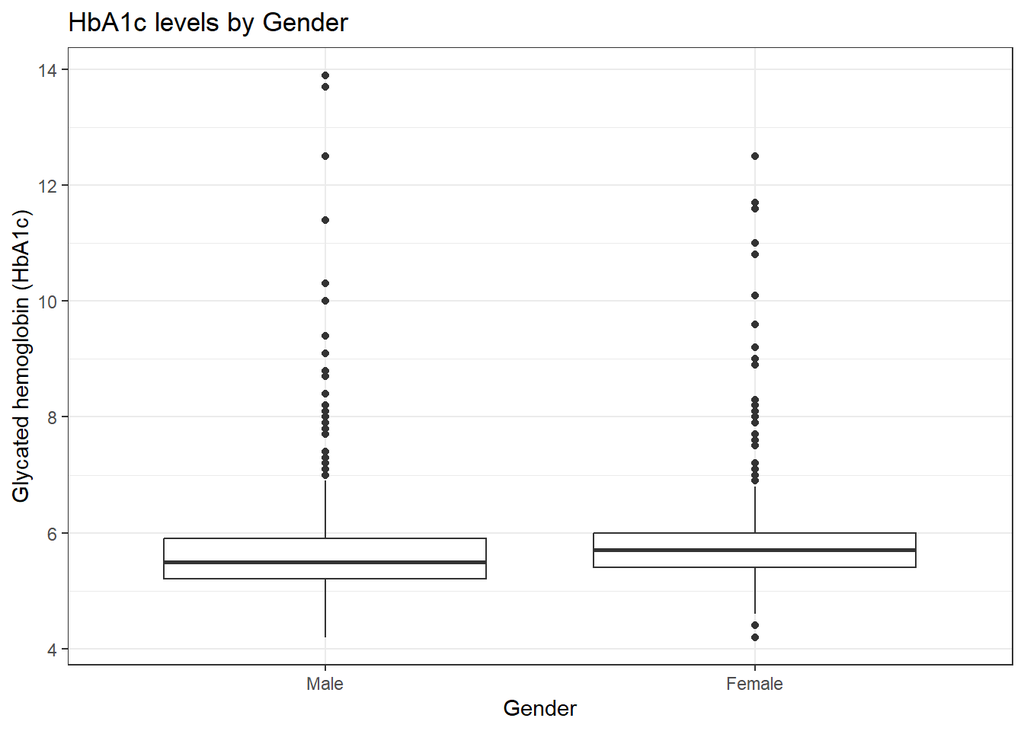

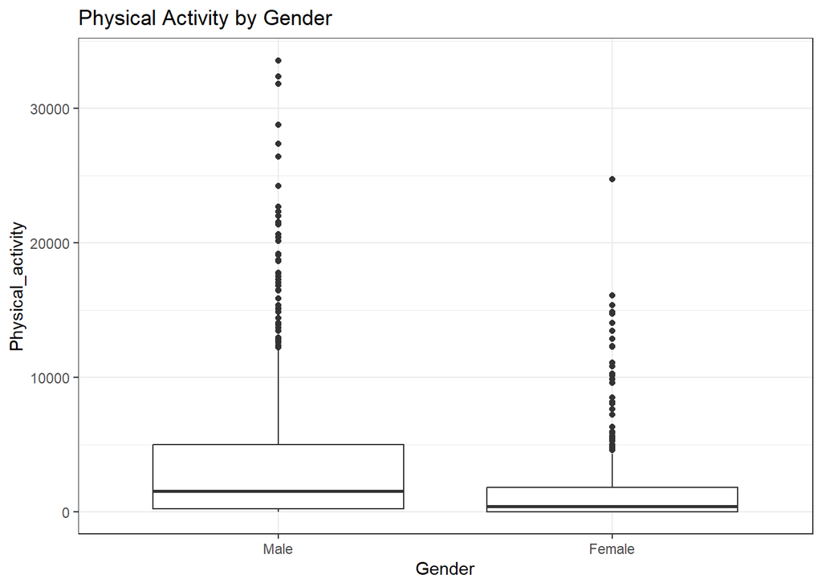

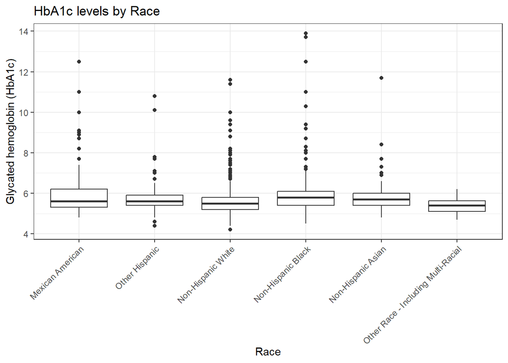

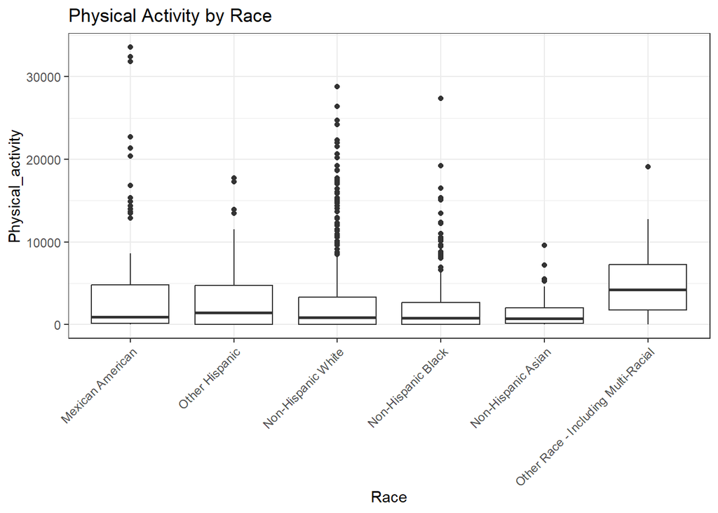

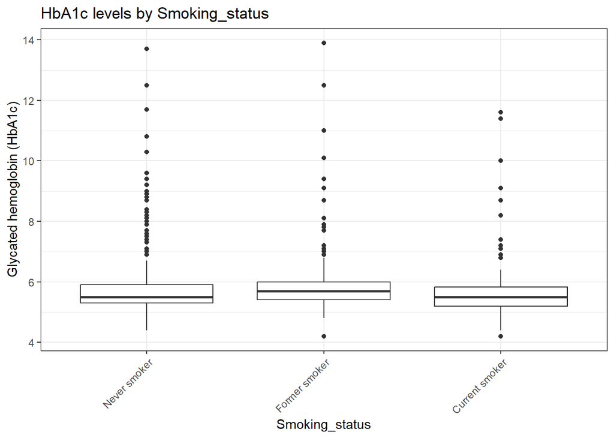

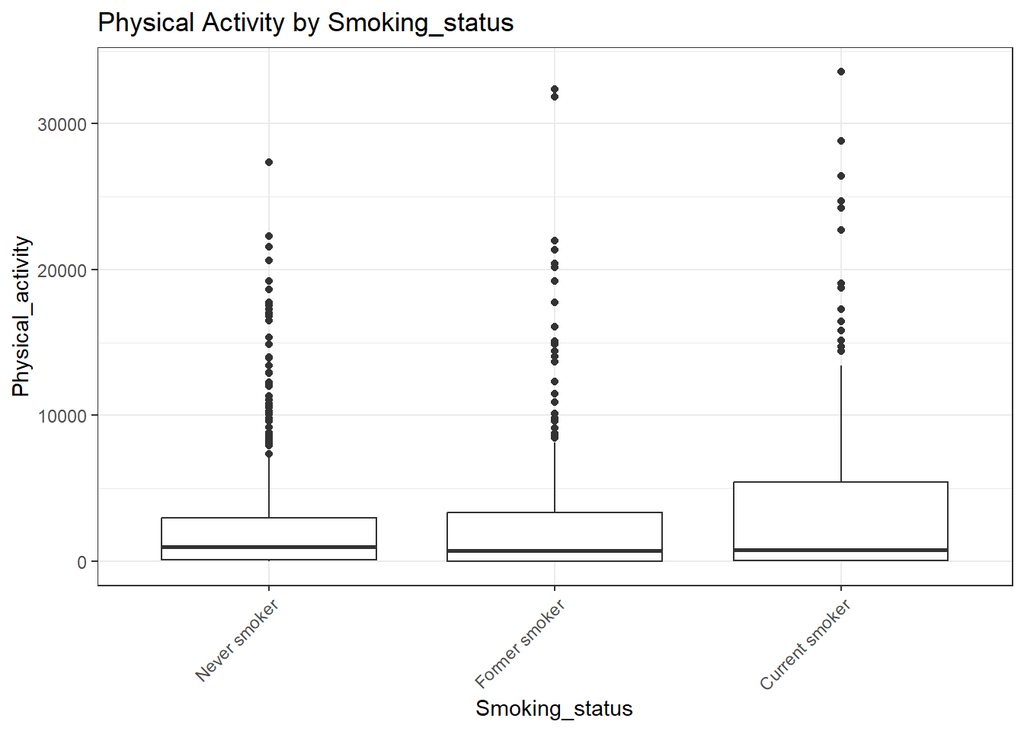

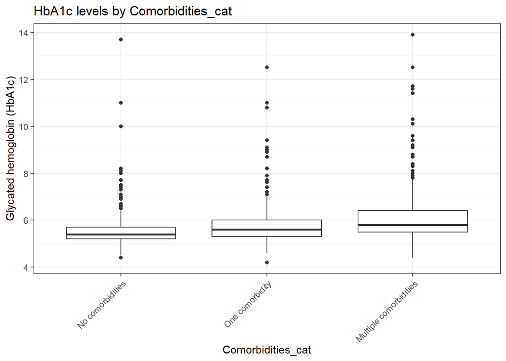

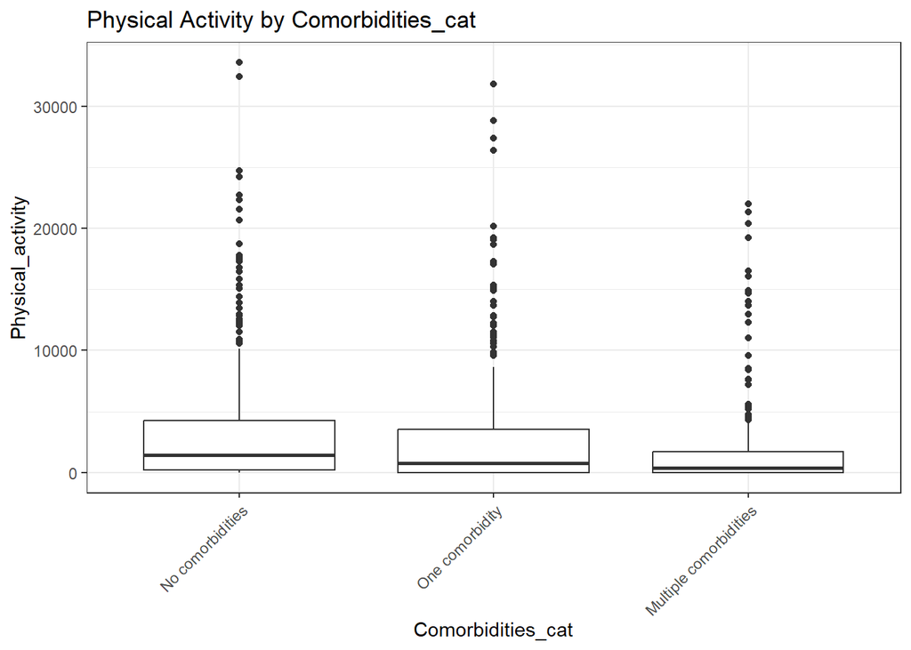

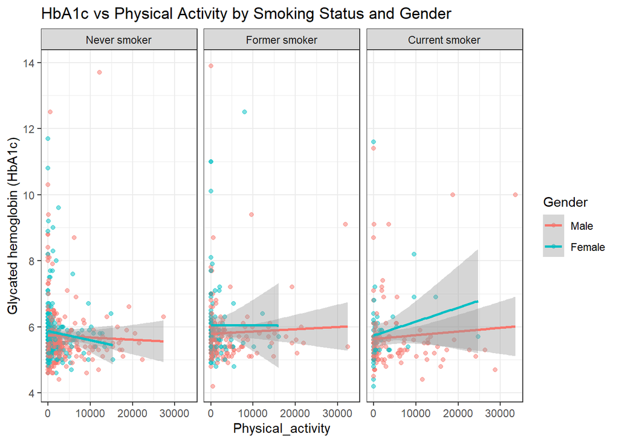

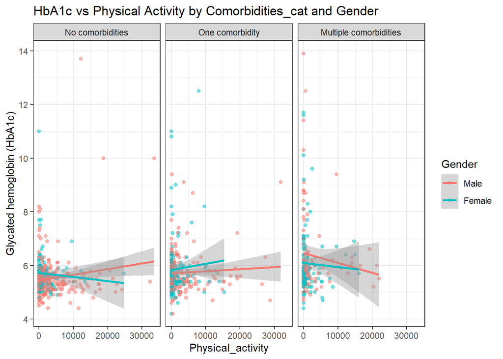

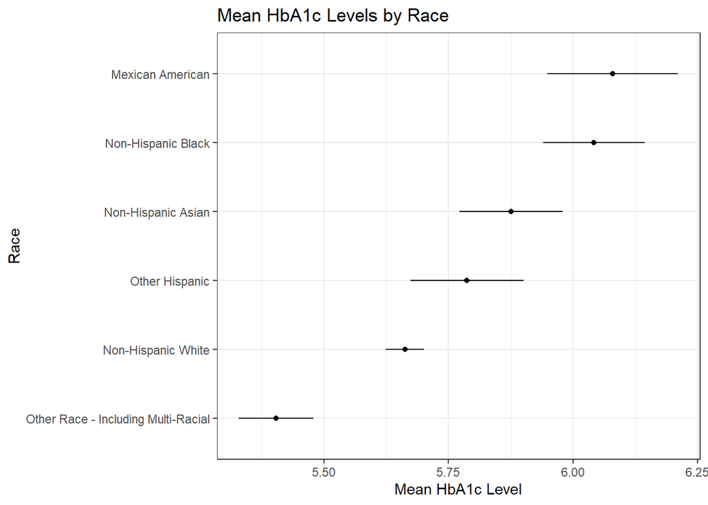

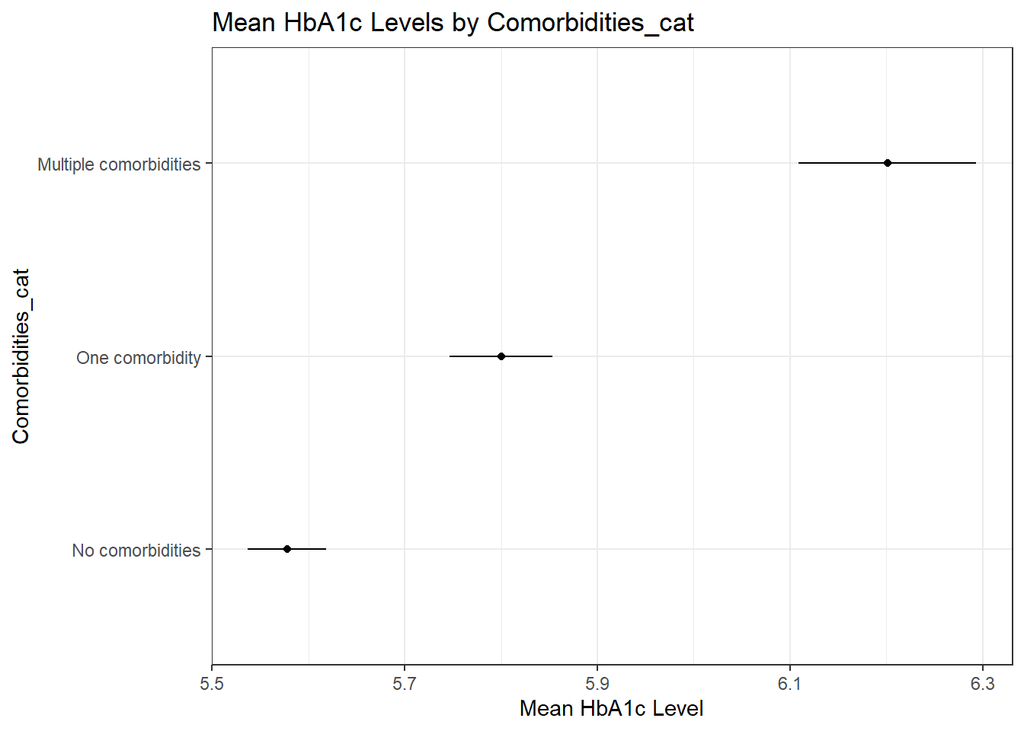

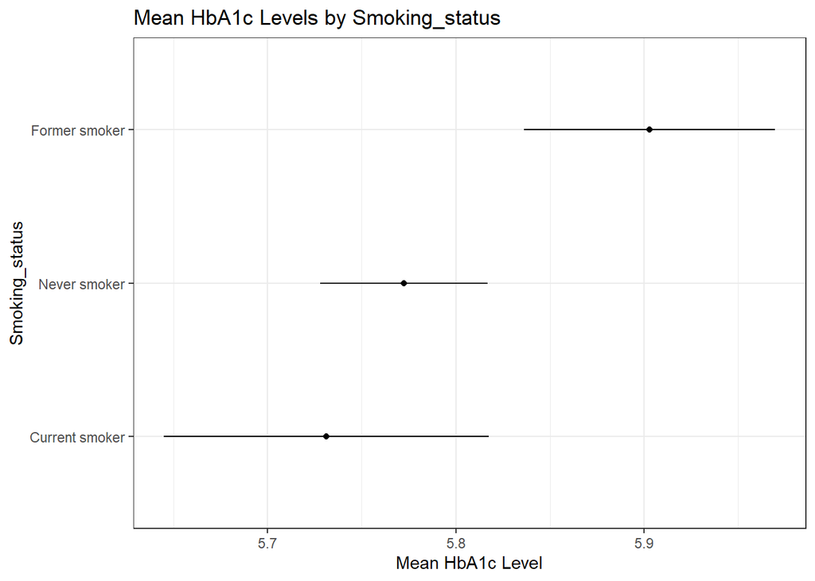

## **Линейная модель с ковариатами**

```
##
## Call:
## lm(formula = `Glycated hemoglobin (HbA1c)` ~ Physical_activity +
##     Gender + Race + Smoking_status + Comorbidities_cat, data = HW_model)
##
## Coefficients:
##                             (Intercept)
##                               5.815e+00
##                       Physical_activity
##                               6.403e-06
##                            GenderFemale
##                               6.343e-02
##                      RaceOther Hispanic
##                              -2.948e-01
##                  RaceNon-Hispanic White
##                              -4.852e-01
##                  RaceNon-Hispanic Black
##                              -8.205e-02
##                  RaceNon-Hispanic Asian
##                              -1.246e-01
## RaceOther Race - Including Multi-Racial
##                              -6.026e-01
##             Smoking_statusFormer smoker
##                               8.875e-02
##            Smoking_statusCurrent smoker
##                              -6.280e-03
##        Comorbidities_catOne comorbidity
##                               2.227e-01
## Comorbidities_catMultiple comorbidities
##                               6.401e-01
```

```
##
## Call:
## lm(formula = `Glycated hemoglobin (HbA1c)` ~ Physical_activity +
##     Gender + Race + Smoking_status + Comorbidities_cat, data = HW_model)
##
## Residuals:
##     Min      1Q  Median      3Q     Max
## -1.7606 -0.4777 -0.1613  0.1569  7.8883
##
## Coefficients:
##                                           Estimate Std. Error t value Pr(>|t|)
## (Intercept)                              5.815e+00  1.157e-01  50.283  < 2e-16
## Physical_activity                        6.403e-06  6.928e-06   0.924  0.35560
## GenderFemale                             6.343e-02  7.105e-02   0.893  0.37217
## RaceOther Hispanic                      -2.948e-01  1.516e-01  -1.945  0.05211
## RaceNon-Hispanic White                  -4.852e-01  1.097e-01  -4.425 1.08e-05
## RaceNon-Hispanic Black                  -8.205e-02  1.250e-01  -0.657  0.51161
## RaceNon-Hispanic Asian                  -1.246e-01  1.512e-01  -0.824  0.41013
## RaceOther Race - Including Multi-Racial -6.026e-01  2.256e-01  -2.671  0.00770
## Smoking_statusFormer smoker              8.875e-02  7.764e-02   1.143  0.25330
## Smoking_statusCurrent smoker            -6.280e-03  9.079e-02  -0.069  0.94487
## Comorbidities_catOne comorbidity         2.227e-01  7.771e-02   2.866  0.00426
## Comorbidities_catMultiple comorbidities  6.401e-01  8.849e-02   7.233 1.00e-12
##
## (Intercept)                             ***
## Physical_activity
## GenderFemale
## RaceOther Hispanic                      .
## RaceNon-Hispanic White                  ***
## RaceNon-Hispanic Black
## RaceNon-Hispanic Asian
## RaceOther Race - Including Multi-Racial **
## Smoking_statusFormer smoker
## Smoking_statusCurrent smoker
## Comorbidities_catOne comorbidity        **
## Comorbidities_catMultiple comorbidities ***
## ---
## Signif. codes:  0 '***' 0.001 '**' 0.01 '*' 0.05 '.' 0.1 ' ' 1
##
## Residual standard error: 0.9904 on 904 degrees of freedom
## Multiple R-squared:  0.09531,    Adjusted R-squared:  0.0843
## F-statistic: 8.658 on 11 and 904 DF,  p-value: 1.064e-14
```

```
## # A tibble: 12 × 7
##    term                estimate std.error statistic   p.value conf.low conf.high
##    <chr>                  <dbl>     <dbl>     <dbl>     <dbl>    <dbl>     <dbl>
##  1 (Intercept)          5.82e+0   1.16e-1   50.3    3.90e-264  5.59e+0   6.04e+0
##  2 Physical_activity    6.40e-6   6.93e-6    0.924  3.56e-  1 -7.19e-6   2.00e-5
##  3 GenderFemale         6.34e-2   7.10e-2    0.893  3.72e-  1 -7.60e-2   2.03e-1
##  4 RaceOther Hispanic  -2.95e-1   1.52e-1   -1.94   5.21e-  2 -5.92e-1   2.70e-3
##  5 RaceNon-Hispanic W… -4.85e-1   1.10e-1   -4.42   1.08e-  5 -7.00e-1  -2.70e-1
##  6 RaceNon-Hispanic B… -8.21e-2   1.25e-1   -0.657  5.12e-  1 -3.27e-1   1.63e-1
##  7 RaceNon-Hispanic A… -1.25e-1   1.51e-1   -0.824  4.10e-  1 -4.21e-1   1.72e-1
##  8 RaceOther Race - I… -6.03e-1   2.26e-1   -2.67   7.70e-  3 -1.05e+0  -1.60e-1
##  9 Smoking_statusForm…  8.88e-2   7.76e-2    1.14   2.53e-  1 -6.36e-2   2.41e-1
## 10 Smoking_statusCurr… -6.28e-3   9.08e-2   -0.0692 9.45e-  1 -1.84e-1   1.72e-1
## 11 Comorbidities_catO…  2.23e-1   7.77e-2    2.87   4.26e-  3  7.02e-2   3.75e-1
## 12 Comorbidities_catM…  6.40e-1   8.85e-2    7.23   1.00e- 12  4.66e-1   8.14e-1
```

```
## # A tibble: 6 × 12
##   `Glycated hemoglobin (HbA1c)` Physical_activity Gender Race     Smoking_status
##                           <dbl>             <dbl> <fct>  <fct>    <fct>
## 1                           6.2              1120 Female Non-His… Never smoker
## 2                           5.6              6120 Male   Non-His… Never smoker
## 3                           5.2             14400 Male   Non-His… Current smoker
## 4                           5.8              4800 Male   Non-His… Never smoker
## 5                           5.2              9660 Male   Non-His… Never smoker
## 6                           5.3                 0 Male   Non-His… Never smoker
## # ℹ 7 more variables: Comorbidities_cat <fct>, .fitted <dbl>, .resid <dbl>,
## #   .hat <dbl>, .sigma <dbl>, .cooksd <dbl>, .std.resid <dbl>
```

```
## # A tibble: 1 × 12
##   r.squared adj.r.squared sigma statistic  p.value    df logLik   AIC   BIC
##       <dbl>         <dbl> <dbl>     <dbl>    <dbl> <dbl>  <dbl> <dbl> <dbl>
## 1    0.0953        0.0843 0.990      8.66 1.06e-14    11 -1285. 2596. 2658.
## # ℹ 3 more variables: deviance <dbl>, df.residual <int>, nobs <int>
```

### **Интерпретация полученной модели с ковариатами**

Physical_activity: β = 6.403e-06 (p = 0.356) Очень малый и статистически незначимый эффект физической активности.

У не-испаноязычных белых уровень HbA1c в среднем на 0.49 единиц ниже, чем у мексиканских американцев. У представителей других рас уровень HbA1c в среднем на 0.60 единиц ниже.

Сопутствующие заболевания: при наличии одного сопутствующего заболевания уровень HbA1c в среднем на 0.22 единицы выше. При наличии множественных сопутствующих заболеваний уровень HbA1c в среднем на 0.64 единицы выше.

Gender: нет статистически значимых различий между полами.

Smoking_status (референтная группа - Never smoker): Статус курения не показывает значимой связи с уровнем HbA1c.

Диагностика остатков: Min: -1.7606, Max: 7.8883. Большой разброс остатков и наличие экстремальных значений указывают на проблемы с моделью. Медиана остатков (-0.1613) отлична от нуля, что говорит о возможной систематической ошибке. Низкий R-squared указывает на слабую объяснительную способность модели.

### **Диагностика модели с ковариатами**

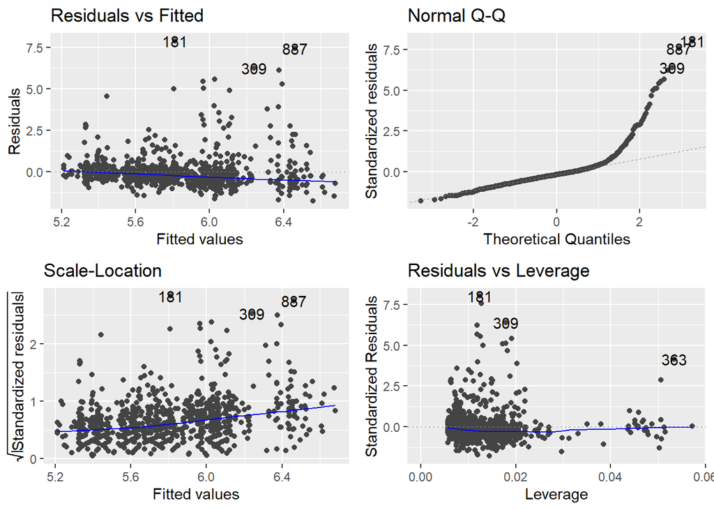

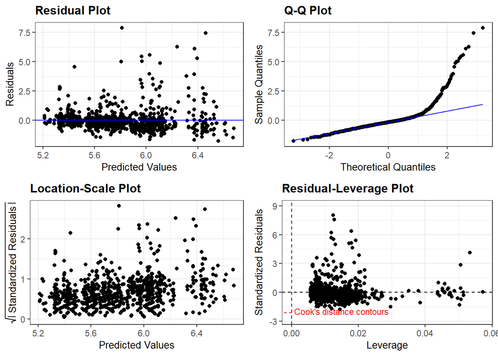

#### QQ-plot и гистограмма

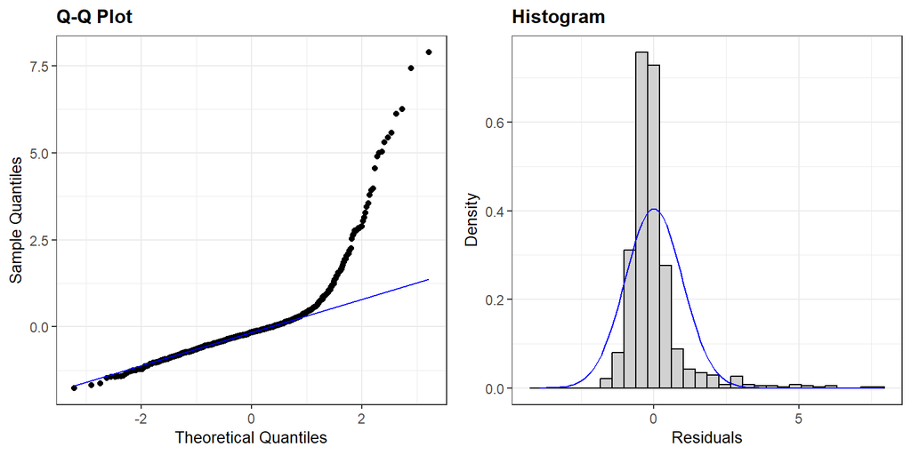

#### Residuals vs Leverage

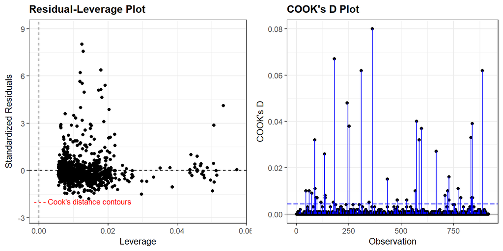

#### Мультиколлинеарность

```
##                       GVIF Df GVIF^(1/(2*Df))
## Physical_activity 1.087776  1        1.042965
## Gender            1.141447  1        1.068385
## Race              1.101546  5        1.009718
## Smoking_status    1.078222  2        1.019007
## Comorbidities_cat 1.134008  2        1.031939
```

Проанализируем диагностические графики:

QQ-plot и гистограмма остатков: показывает отклонение от нормальности распределения остатков, особенно на “хвостах”. Гистограмма остатков показывает правостороннюю асимметрию.

Residual plot показывает неравномерное распределение остатков. Residual-Leverage plot указывает на наличие влиятельных наблюдений. Распределение переменных: Обе количественные переменные имеют сильно асимметричное распределение. Между ними очень низкая корреляция (-0.007). Vif: проблемы c мультиколлинеарностью нет.

## **Линейная модель без ковариат**

```
##
## Call:
## lm(formula = `Glycated hemoglobin (HbA1c)` ~ Physical_activity,
##     data = HW_model)
##
## Coefficients:
##       (Intercept)  Physical_activity
##         5.807e+00         -1.367e-06
```

```
##
## Call:
## lm(formula = `Glycated hemoglobin (HbA1c)` ~ Physical_activity,
##     data = HW_model)
##
## Residuals:
##     Min      1Q  Median      3Q     Max
## -1.6067 -0.5060 -0.2067  0.1071  8.0933
##
## Coefficients:
##                     Estimate Std. Error t value Pr(>|t|)
## (Intercept)        5.807e+00  3.998e-02 145.252   <2e-16 ***
## Physical_activity -1.367e-06  6.945e-06  -0.197    0.844
## ---
## Signif. codes:  0 '***' 0.001 '**' 0.01 '*' 0.05 '.' 0.1 ' ' 1
##
## Residual standard error: 1.036 on 914 degrees of freedom
## Multiple R-squared:  4.24e-05,   Adjusted R-squared:  -0.001052
## F-statistic: 0.03876 on 1 and 914 DF,  p-value: 0.844
```

```
## # A tibble: 2 × 7
##   term                 estimate  std.error statistic p.value  conf.low conf.high
##   <chr>                   <dbl>      <dbl>     <dbl>   <dbl>     <dbl>     <dbl>
## 1 (Intercept)        5.81       0.0400       145.      0       5.73e+0 5.89
## 2 Physical_activity -0.00000137 0.00000695    -0.197   0.844  -1.50e-5 0.0000123
```

```
## # A tibble: 6 × 8
##   Glycated hemoglobin (HbA1c…¹ Physical_activity .fitted   .resid    .hat .sigma
##                          <dbl>             <dbl>   <dbl>    <dbl>   <dbl>  <dbl>
## 1                          6.2              1120    5.81  3.95e-1 0.00125   1.04
## 2                          5.6              6120    5.80 -1.98e-1 0.00154   1.04
## 3                          5.2             14400    5.79 -5.87e-1 0.00696   1.04
## 4                          5.8              4800    5.80 -1.27e-4 0.00124   1.04
## 5                          5.2              9660    5.79 -5.93e-1 0.00310   1.04
## 6                          5.3                 0    5.81 -5.07e-1 0.00149   1.04
## # ℹ abbreviated name: ¹`Glycated hemoglobin (HbA1c)`
## # ℹ 2 more variables: .cooksd <dbl>, .std.resid <dbl>
```

```
## # A tibble: 1 × 12
##   r.squared adj.r.squared sigma statistic p.value    df logLik   AIC   BIC
##       <dbl>         <dbl> <dbl>     <dbl>   <dbl> <dbl>  <dbl> <dbl> <dbl>
## 1 0.0000424      -0.00105  1.04    0.0388   0.844     1 -1331. 2668. 2682.
## # ℹ 3 more variables: deviance <dbl>, df.residual <int>, nobs <int>
```

### **Диагностика модели без ковариат**

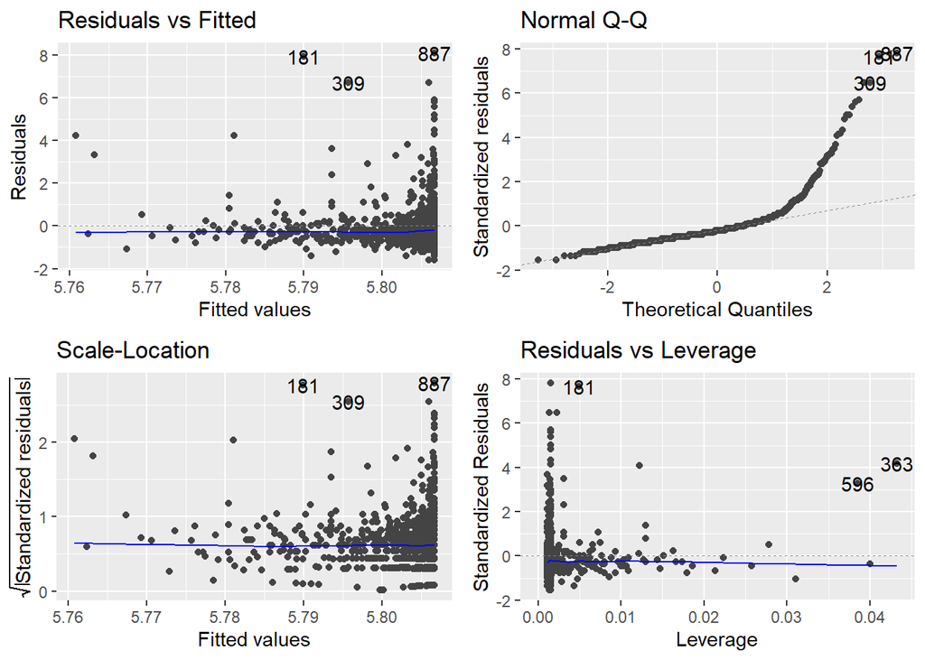

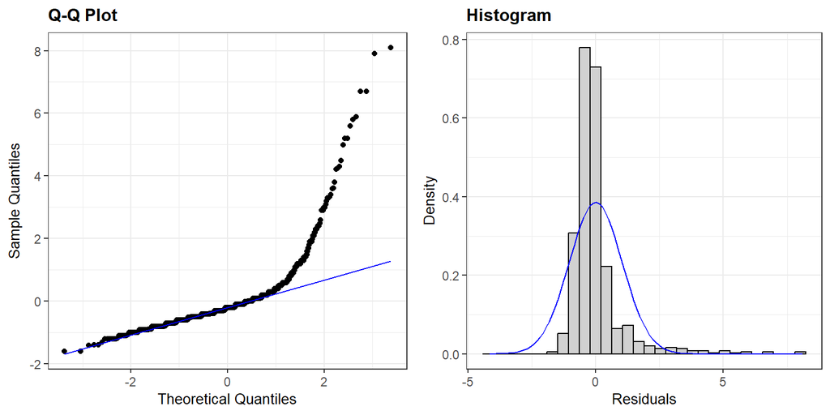

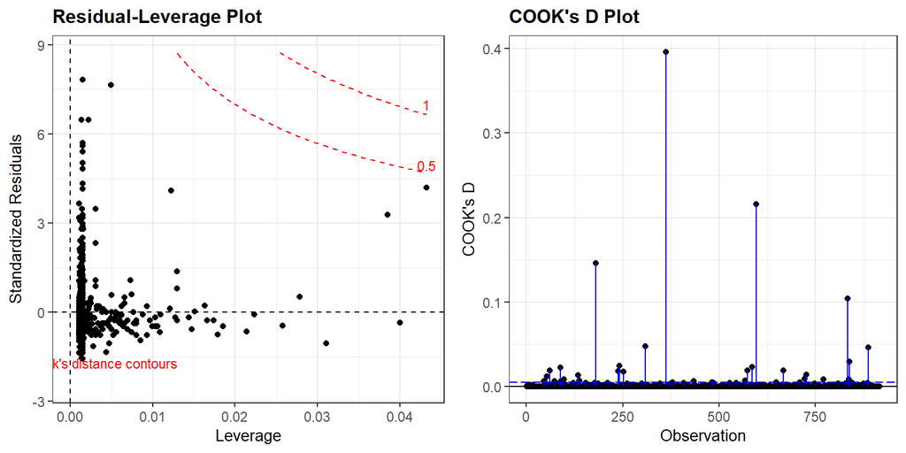

### **Интерпретация полученной модели без ковариат**

Добавление ковариат значительно улучшило объяснительную способность модели (R² вырос с ≈0% до 9.5%) Модель с ковариатами статистически значима (p < 0.001). Модель без ковариат статистически незначима. Эта модель не лучше, чем простое среднее значение (включение физической активности не улучшает предсказательную способность модели без ковариат).

Изменение эффекта физической активности: Без ковариат: -1.367e-06 (p = 0.844). С ковариатами: 6.403e-06 (p = 0.356). Направление эффекта изменилось на противоположное. В обеих моделях эффект статистически незначим. Это показывает, что сама по себе физическая активность (без учета других факторов) не объясняет вариацию в уровне HbA1c, но модель становится информативной при добавлении других предикторов. Обе модели имеют проблемы с нормальностью распределения остатков и гомоскедастичностью, с выбросами и влиятельными наблюдениями .

## **Преобразование переменных**

Для улучшения модели приняты решения преодразовать переменные следующим образом:

Physical_activity - логарифмирование, т.к.: данные сильно скошены вправо (long right tail); большая концентрация значений в левой части распределения; наличие экстремальных значений справа.

Используется log1p() вместо простого log() по следующим причинам: безопасно работает с нулевыми значениями (log(0) не определен, а log1p(0) = 0); Для малых значений x, log1p(x) ≈ x, что сохраняет интерпретируемость; Помогает справиться с проблемой гетероскедастичности.

После логарифмирования распределение должно стать более симметричным, выбросы должны оказывать меньшее влияние, связь с другими переменными может стать более линейной.

Для Glycated hemoglobin (HbA1c) выбрано Box-Cox преобразование выбрано по следующим причинам:

На гистограмме видно правостороннее (положительное) скошенное распределение, Box-Cox хорошо работает именно с такими распределениями. HbA1c всегда имеет положительные значения, Box-Cox предназначен именно для положительных данных. Гибкость преобразования: Box-Cox автоматически подбирает оптимальный параметр λ. При λ = 0 получаем логарифмическое преобразование, при λ = 1 получаем линейное преобразование, при λ = 0.5 получаем квадратный корень.

Box-Cox преобразование - это семейство степенных преобразований, которое помогает сделать распределение данных более близким к нормальному. Оно определяется формулой:

y(λ) = (y^λ - 1)/λ, если λ ≠ 0 y(λ) = log(y), если λ = 0

где:

y - исходные данные λ (лямбда) - параметр преобразования y(λ) - преобразованные данные.

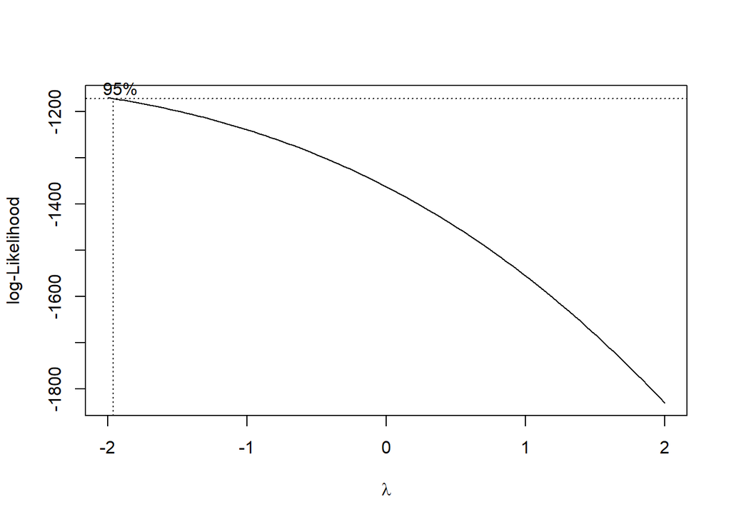

## **Модель после преобразования переменных, с ковариатами**

```
##
## Call:
## lm(formula = HbA1c_transformed ~ Physical_activity_log + Gender +
##     Race + Smoking_status + Comorbidities_cat, data = HW_model)
##
## Coefficients:
##                             (Intercept)
##                               4.848e-01
##                   Physical_activity_log
##                              -7.687e-05
##                            GenderFemale
##                               2.820e-04
##                      RaceOther Hispanic
##                              -1.122e-03
##                  RaceNon-Hispanic White
##                              -1.861e-03
##                  RaceNon-Hispanic Black
##                              -3.568e-04
##                  RaceNon-Hispanic Asian
##                              -2.018e-04
## RaceOther Race - Including Multi-Racial
##                              -2.123e-03
##             Smoking_statusFormer smoker
##                               4.577e-04
##            Smoking_statusCurrent smoker
##                              -2.837e-04
##        Comorbidities_catOne comorbidity
##                               9.107e-04
## Comorbidities_catMultiple comorbidities
##                               2.297e-03
```

```
##
## Call:
## lm(formula = HbA1c_transformed ~ Physical_activity_log + Gender +
##     Race + Smoking_status + Comorbidities_cat, data = HW_model)
##
## Residuals:
##        Min         1Q     Median         3Q        Max
## -0.0121801 -0.0018804 -0.0001714  0.0015396  0.0136292
##
## Coefficients:
##                                           Estimate Std. Error  t value Pr(>|t|)
## (Intercept)                              4.848e-01  4.453e-04 1088.591  < 2e-16
## Physical_activity_log                   -7.687e-05  3.377e-05   -2.276 0.023062
## GenderFemale                             2.820e-04  2.424e-04    1.163 0.244973
## RaceOther Hispanic                      -1.122e-03  5.185e-04   -2.165 0.030683
## RaceNon-Hispanic White                  -1.861e-03  3.743e-04   -4.972 7.95e-07
## RaceNon-Hispanic Black                  -3.568e-04  4.259e-04   -0.838 0.402430
## RaceNon-Hispanic Asian                  -2.018e-04  5.133e-04   -0.393 0.694264
## RaceOther Race - Including Multi-Racial -2.123e-03  7.724e-04   -2.748 0.006110
## Smoking_statusFormer smoker              4.577e-04  2.658e-04    1.722 0.085410
## Smoking_statusCurrent smoker            -2.837e-04  3.100e-04   -0.915 0.360287
## Comorbidities_catOne comorbidity         9.107e-04  2.667e-04    3.415 0.000665
## Comorbidities_catMultiple comorbidities  2.297e-03  3.053e-04    7.524 1.28e-13
##
## (Intercept)                             ***
## Physical_activity_log                   *
## GenderFemale
## RaceOther Hispanic                      *
## RaceNon-Hispanic White                  ***
## RaceNon-Hispanic Black
## RaceNon-Hispanic Asian
## RaceOther Race - Including Multi-Racial **
## Smoking_statusFormer smoker             .
## Smoking_statusCurrent smoker
## Comorbidities_catOne comorbidity        ***
## Comorbidities_catMultiple comorbidities ***
## ---
## Signif. codes:  0 '***' 0.001 '**' 0.01 '*' 0.05 '.' 0.1 ' ' 1
##
## Residual standard error: 0.003388 on 904 degrees of freedom
## Multiple R-squared:  0.1281, Adjusted R-squared:  0.1175
## F-statistic: 12.08 on 11 and 904 DF,  p-value: < 2.2e-16
```

```
## # A tibble: 12 × 7
##    term                 estimate std.error statistic  p.value conf.low conf.high
##    <chr>                   <dbl>     <dbl>     <dbl>    <dbl>    <dbl>     <dbl>
##  1 (Intercept)           4.85e-1 0.000445   1089.    0         4.84e-1   4.86e-1
##  2 Physical_activity_l… -7.69e-5 0.0000338    -2.28  2.31e- 2 -1.43e-4  -1.06e-5
##  3 GenderFemale          2.82e-4 0.000242      1.16  2.45e- 1 -1.94e-4   7.58e-4
##  4 RaceOther Hispanic   -1.12e-3 0.000518     -2.16  3.07e- 2 -2.14e-3  -1.05e-4
##  5 RaceNon-Hispanic Wh… -1.86e-3 0.000374     -4.97  7.95e- 7 -2.60e-3  -1.13e-3
##  6 RaceNon-Hispanic Bl… -3.57e-4 0.000426     -0.838 4.02e- 1 -1.19e-3   4.79e-4
##  7 RaceNon-Hispanic As… -2.02e-4 0.000513     -0.393 6.94e- 1 -1.21e-3   8.06e-4
##  8 RaceOther Race - In… -2.12e-3 0.000772     -2.75  6.11e- 3 -3.64e-3  -6.07e-4
##  9 Smoking_statusForme…  4.58e-4 0.000266      1.72  8.54e- 2 -6.39e-5   9.79e-4
## 10 Smoking_statusCurre… -2.84e-4 0.000310     -0.915 3.60e- 1 -8.92e-4   3.25e-4
## 11 Comorbidities_catOn…  9.11e-4 0.000267      3.42  6.65e- 4  3.87e-4   1.43e-3
## 12 Comorbidities_catMu…  2.30e-3 0.000305      7.52  1.28e-13  1.70e-3   2.90e-3
```

```
## # A tibble: 6 × 12
##   HbA1c_transformed Physical_activity_log Gender Race             Smoking_status
##               <dbl>                 <dbl> <fct>  <fct>            <fct>
## 1             0.487                  7.02 Female Non-Hispanic Wh… Never smoker
## 2             0.484                  8.72 Male   Non-Hispanic Bl… Never smoker
## 3             0.482                  9.58 Male   Non-Hispanic Wh… Current smoker
## 4             0.485                  8.48 Male   Non-Hispanic Wh… Never smoker
## 5             0.482                  9.18 Male   Non-Hispanic Bl… Never smoker
## 6             0.482                  0    Male   Non-Hispanic As… Never smoker
## # ℹ 7 more variables: Comorbidities_cat <fct>, .fitted <dbl>, .resid <dbl>,
## #   .hat <dbl>, .sigma <dbl>, .cooksd <dbl>, .std.resid <dbl>
```

```
## # A tibble: 1 × 12
##   r.squared adj.r.squared   sigma statistic  p.value    df logLik    AIC    BIC
##       <dbl>         <dbl>   <dbl>     <dbl>    <dbl> <dbl>  <dbl>  <dbl>  <dbl>
## 1     0.128         0.118 0.00339      12.1 2.21e-21    11  3916. -7806. -7743.
## # ℹ 3 more variables: deviance <dbl>, df.residual <int>, nobs <int>
```

### **Интерпретация модели после преобразования переменных, с ковариатами**

Остатки стали более симметричными и меньше по абсолютной величине (Min: -0.0122, Max: 0.0136).

Теперь физическая активность стала значимым предиктором, что совпадает с изначальными предположениями. При увеличении логарифма физической активности на единицу, преобразованный уровень HbA1c снижается на 0.00007687 единиц.

Статус курения и пол остаются незначимым предикторами.

Точечная и интервальная оценки: Точечная оценка - это конкретное значение коэффициента в модели. В нашем случае для логарифма физической активности это β = -7.687e-05 Интервальная оценка - это 95% доверительный интервал, [-1.431424e-04 -0.0000105930]

Точечная оценка:

Интервальная оценка:

С 95% уверенностью мы можем сказать, что истинный эффект увеличения логарифма физической активности на единицу находится между снижением HbA1c на 0.000143 и 0.0000107 единиц. Поскольку интервал не включает 0, эффект статистически значим (что подтверждается p-value = 0.023).

Выводы:

Из точечной оценки:

Мы видим отрицательную связь между физической активностью и уровнем HbA1c. Но эффект очень маленький в абсолютных значениях.

Из интервальной оценки:

Мы можем быть уверены в направлении эффекта (он отрицательный). Размер эффекта достаточно стабилен (узкий доверительный интервал).

Клиническая значимость: Чтобы определить клиническую значимость, нам не хватает:

Информации о минимальном клинически значимом различии (MCID) для HbA1c; Типичного диапазона значений физической активности в выборке; Экспертного мнения клиницистов о том, какое изменение HbA1c считается существенным для здоровья пациента.

Для более точной оценки клинической значимости было бы полезно:

Получить консультацию эндокринолога. Найти в литературе данные о клинически значимых изменениях HbA1c. Пересчитать эффекты в более понятных единицах измерения (например, сколько дополнительных минут физической активности нужно для снижения HbA1c на 0.1%). В текущем виде, учитывая малую величину эффекта, можно предположить, что клиническая значимость невелика, но для окончательного вывода нужна дополнительная информация.

### **Диагностика модели после преобразования переменных, с ковариатами**

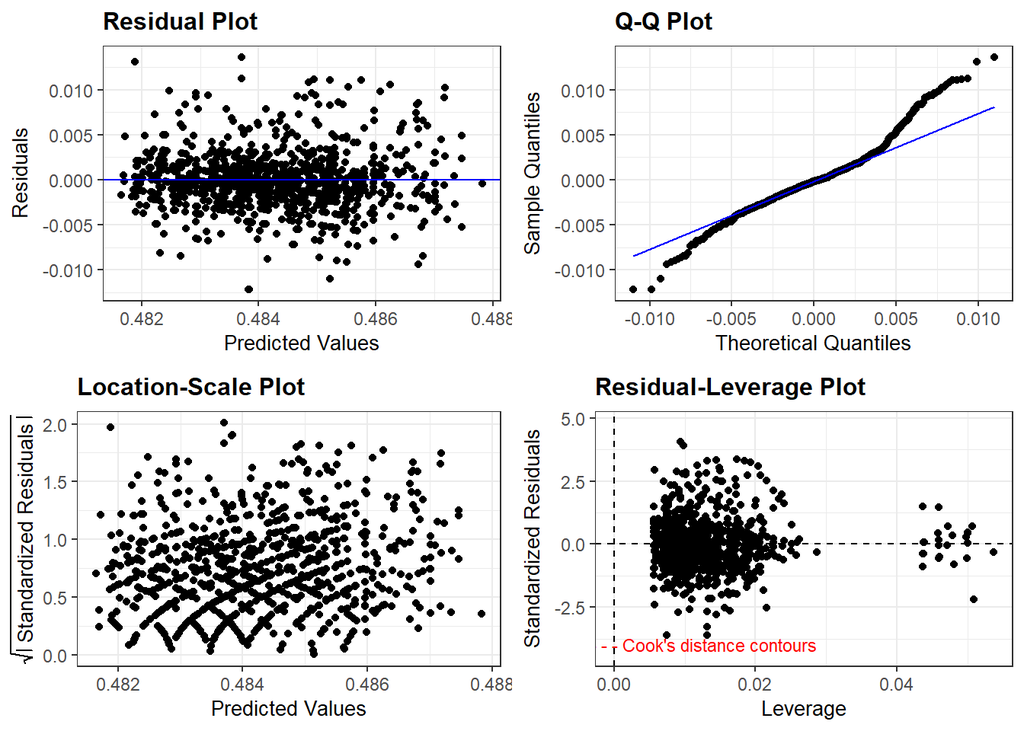

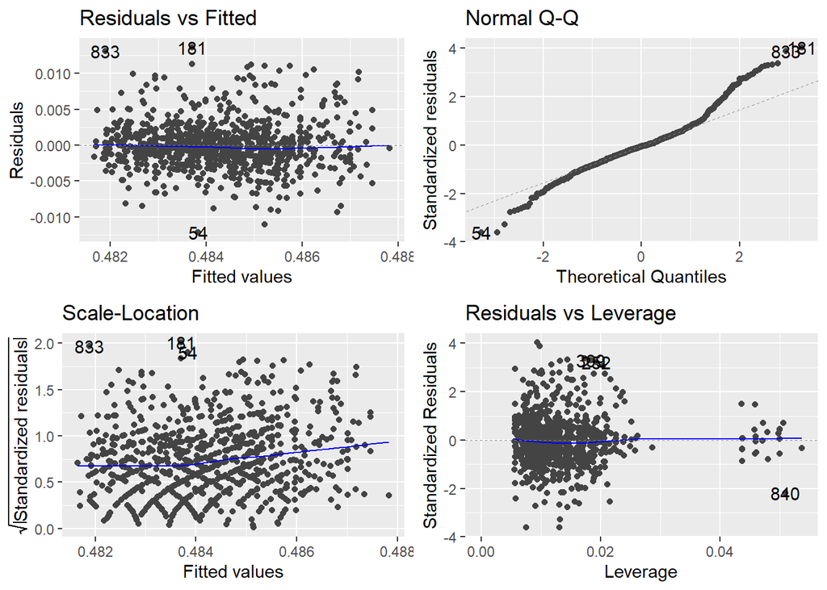

#### QQ-plot и гистограмма

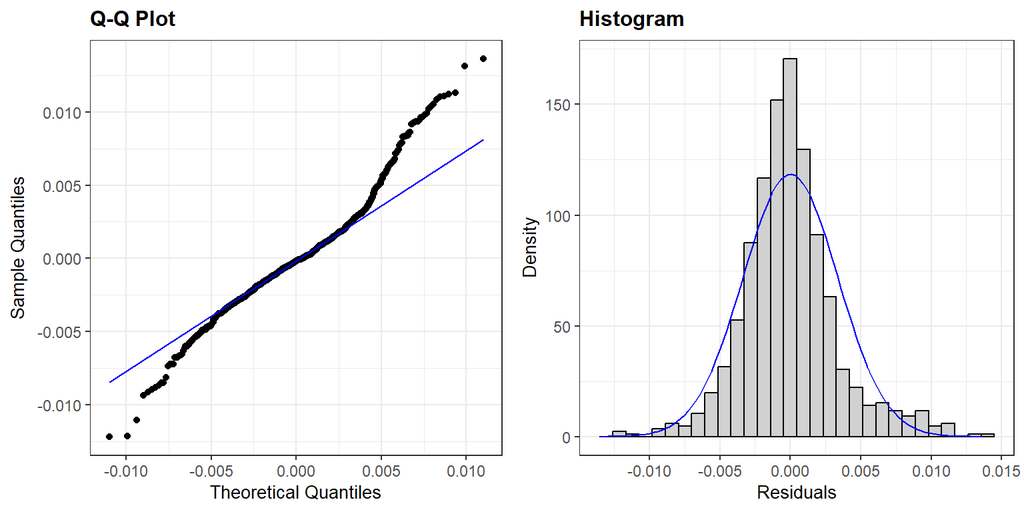

#### Residuals vs Leverage

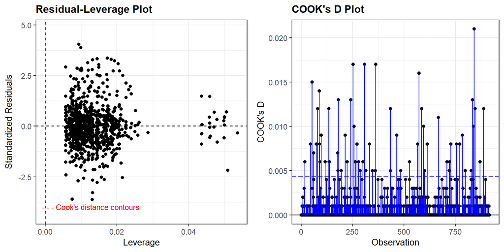

#### Мультиколлинеарность

```
##                           GVIF Df GVIF^(1/(2*Df))
## Physical_activity_log 1.086703  1        1.042451
## Gender                1.135385  1        1.065545
## Race                  1.082298  5        1.007940
## Smoking_status        1.074550  2        1.018138
## Comorbidities_cat     1.153239  2        1.036286
```

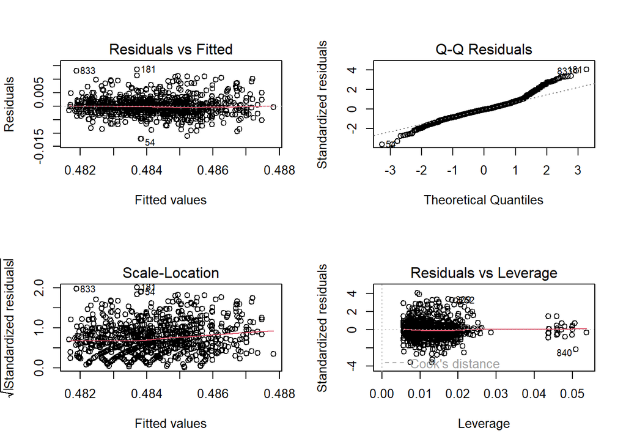

Преобразования существенно улучшили модель. Основные предположения линейной регрессии теперь выполняются лучше: нормальность остатков, гомоскедастичность, линейность связи.

В целом, после преобразований модель выглядит намного лучше и может быть использована для анализа. Оставшиеся отклонения от идеальных предположений не критичны и типичны для реальных данных.

```
##
## Call:
## lm(formula = HbA1c_transformed ~ Physical_activity_log + Gender +
##     Race + Smoking_status + Comorbidities_cat, data = HW_model)
##
## Residuals:
##        Min         1Q     Median         3Q        Max
## -0.0121801 -0.0018804 -0.0001714  0.0015396  0.0136292
##
## Coefficients:
##                                           Estimate Std. Error  t value Pr(>|t|)
## (Intercept)                              4.848e-01  4.453e-04 1088.591  < 2e-16
## Physical_activity_log                   -7.687e-05  3.377e-05   -2.276 0.023062
## GenderFemale                             2.820e-04  2.424e-04    1.163 0.244973
## RaceOther Hispanic                      -1.122e-03  5.185e-04   -2.165 0.030683
## RaceNon-Hispanic White                  -1.861e-03  3.743e-04   -4.972 7.95e-07
## RaceNon-Hispanic Black                  -3.568e-04  4.259e-04   -0.838 0.402430
## RaceNon-Hispanic Asian                  -2.018e-04  5.133e-04   -0.393 0.694264
## RaceOther Race - Including Multi-Racial -2.123e-03  7.724e-04   -2.748 0.006110
## Smoking_statusFormer smoker              4.577e-04  2.658e-04    1.722 0.085410
## Smoking_statusCurrent smoker            -2.837e-04  3.100e-04   -0.915 0.360287
## Comorbidities_catOne comorbidity         9.107e-04  2.667e-04    3.415 0.000665
## Comorbidities_catMultiple comorbidities  2.297e-03  3.053e-04    7.524 1.28e-13
##
## (Intercept)                             ***
## Physical_activity_log                   *
## GenderFemale
## RaceOther Hispanic                      *
## RaceNon-Hispanic White                  ***
## RaceNon-Hispanic Black
## RaceNon-Hispanic Asian
## RaceOther Race - Including Multi-Racial **
## Smoking_statusFormer smoker             .
## Smoking_statusCurrent smoker
## Comorbidities_catOne comorbidity        ***
## Comorbidities_catMultiple comorbidities ***
## ---
## Signif. codes:  0 '***' 0.001 '**' 0.01 '*' 0.05 '.' 0.1 ' ' 1
##
## Residual standard error: 0.003388 on 904 degrees of freedom
## Multiple R-squared:  0.1281, Adjusted R-squared:  0.1175
## F-statistic: 12.08 on 11 and 904 DF,  p-value: < 2.2e-16
```

```
##         2.5 %        97.5 %
## -0.0001431424 -0.0000105930
```

```
##
## Linear hypothesis test:
## Physical_activity_log = 0
##
## Model 1: restricted model
## Model 2: HbA1c_transformed ~ Physical_activity_log + Gender + Race + Smoking_status +
##     Comorbidities_cat
##
##   Res.Df      RSS Df  Sum of Sq      F  Pr(>F)
## 1    905 0.010437
## 2    904 0.010378  1 5.9482e-05 5.1815 0.02306 *
## ---
## Signif. codes:  0 '***' 0.001 '**' 0.01 '*' 0.05 '.' 0.1 ' ' 1
```

Формулировка гипотез: H₀: β = 0 (нет связи между физической активностью и HbA1c); H₁: β ≠ 0 (существует связь между физической активностью и HbA1c) Результаты из модели: коэффициент (β) = -7.687e-05; стандартная ошибка = 3.377e-05; t-значение = -2.276; p-значение = 0.023062. Критерии принятия решения: уровень значимости α = 0.05.

95% доверительный интервал: [-1.431424e-04,-0.0000105930] не включает 0.

Мы отвергаем нулевую гипотезу об отсутствии связи. Существует статистически значимая отрицательная ассоциация между физической активностью и уровнем гликированного гемоглобина. Эффект очень малый, но стабильный (узкий доверительный интервал). Статистическая значимость не обязательно означает клиническую значимость, которая, возможно, не очень большая (размер эффекта очень мал, что ставит под вопрос его практическую значимость). Модель объясняет только около 13% вариации в данных, что указывает на наличие других важных факторов.

Результаты теста линейной гипотезы:

Коэффициент при Physical_activity_log = 0; p-значение (0.02306) < 0.05: отвергаем H₀. Включени ев модел ьпоказателя физической активности значимо улучшает модель, но улучшение небольшое (маленькая разница в RSS). Этот тест подтверждает наши предыдущие выводы о наличии статистически значимой, но слабой связи между физической активностью и HbA1c.

```
##
## Call:
## lm(formula = HbA1c_transformed ~ Physical_activity_log * Gender +
##     Race + Smoking_status + Comorbidities_cat, data = HW_model)
##
## Residuals:
##        Min         1Q     Median         3Q        Max
## -0.0121654 -0.0018829 -0.0001704  0.0015461  0.0136462
##
## Coefficients:
##                                           Estimate Std. Error  t value Pr(>|t|)
## (Intercept)                              4.848e-01  4.831e-04 1003.550  < 2e-16
## Physical_activity_log                   -8.169e-05  4.507e-05   -1.812 0.070268
## GenderFemale                             2.240e-04  4.329e-04    0.517 0.604935
## RaceOther Hispanic                      -1.120e-03  5.189e-04   -2.159 0.031132
## RaceNon-Hispanic White                  -1.862e-03  3.746e-04   -4.971 7.96e-07
## RaceNon-Hispanic Black                  -3.585e-04  4.263e-04   -0.841 0.400530
## RaceNon-Hispanic Asian                  -2.058e-04  5.141e-04   -0.400 0.689088
## RaceOther Race - Including Multi-Racial -2.120e-03  7.731e-04   -2.742 0.006226
## Smoking_statusFormer smoker              4.577e-04  2.659e-04    1.721 0.085596
## Smoking_statusCurrent smoker            -2.818e-04  3.103e-04   -0.908 0.364162
## Comorbidities_catOne comorbidity         9.123e-04  2.670e-04    3.417 0.000661
## Comorbidities_catMultiple comorbidities  2.297e-03  3.055e-04    7.519 1.33e-13
## Physical_activity_log:GenderFemale       1.087e-05  6.727e-05    0.162 0.871639
##
## (Intercept)                             ***
## Physical_activity_log                   .
## GenderFemale
## RaceOther Hispanic                      *
## RaceNon-Hispanic White                  ***
## RaceNon-Hispanic Black
## RaceNon-Hispanic Asian
## RaceOther Race - Including Multi-Racial **
## Smoking_statusFormer smoker             .
## Smoking_statusCurrent smoker
## Comorbidities_catOne comorbidity        ***
## Comorbidities_catMultiple comorbidities ***
## Physical_activity_log:GenderFemale
## ---
## Signif. codes:  0 '***' 0.001 '**' 0.01 '*' 0.05 '.' 0.1 ' ' 1
##
## Residual standard error: 0.00339 on 903 degrees of freedom
## Multiple R-squared:  0.1281, Adjusted R-squared:  0.1166
## F-statistic: 11.06 on 12 and 903 DF,  p-value: < 2.2e-16
```

```
## Analysis of Variance Table
##
## Model 1: HbA1c_transformed ~ Physical_activity_log + Gender + Race + Smoking_status +
##     Comorbidities_cat
## Model 2: HbA1c_transformed ~ Physical_activity_log * Gender + Race + Smoking_status +
##     Comorbidities_cat
##   Res.Df      RSS Df Sum of Sq      F Pr(>F)
## 1    904 0.010378
## 2    903 0.010377  1 3.002e-07 0.0261 0.8716
```

Пол не является модификатором эффекта физической активности на уровень HbA1c. Это подтверждается как незначимым коэффициентом взаимодействия, так и тестом отношения правдоподобия (ANOVA). Эффект физической активности статистически одинаков для мужчин и женщин, разница между группами очень мала и статистически незначима. Нет оснований рекомендовать различные подходы к физической активности для мужчин и женщин с точки зрения влияния на HbA1c. Учитывая эти результаты, нет необходимости проводить отдельный анализ для мужчин и женщин, так как эффект физической активности универсален для обоих полов.

## **Модель после преобразования переменных, без ковариат**

```
##
## Call:
## lm(formula = HbA1c_transformed ~ Physical_activity_log, data = HW_model)
##
## Coefficients:
##           (Intercept)  Physical_activity_log
##             0.4850072             -0.0001374
```

```
##
## Call:
## lm(formula = HbA1c_transformed ~ Physical_activity_log, data = HW_model)
##
## Residuals:
##        Min         1Q     Median         3Q        Max
## -0.0133519 -0.0021352 -0.0003965  0.0016448  0.0136219
##
## Coefficients:
##                         Estimate Std. Error  t value Pr(>|t|)
## (Intercept)            0.4850072  0.0002238 2166.656  < 2e-16 ***
## Physical_activity_log -0.0001374  0.0000342   -4.017 6.39e-05 ***
## ---
## Signif. codes:  0 '***' 0.001 '**' 0.01 '*' 0.05 '.' 0.1 ' ' 1
##
## Residual standard error: 0.003577 on 914 degrees of freedom
## Multiple R-squared:  0.01734,    Adjusted R-squared:  0.01627
## F-statistic: 16.13 on 1 and 914 DF,  p-value: 6.39e-05
```

```
## # A tibble: 2 × 7
##   term                   estimate std.error statistic p.value conf.low conf.high
##   <chr>                     <dbl>     <dbl>     <dbl>   <dbl>    <dbl>     <dbl>
## 1 (Intercept)            0.485    0.000224    2167.   0        4.85e-1   4.85e-1
## 2 Physical_activity_log -0.000137 0.0000342     -4.02 6.39e-5 -2.04e-4  -7.02e-5
```

```
## # A tibble: 6 × 8
##   HbA1c_transformed Physical_activity_log .fitted    .resid    .hat  .sigma
##               <dbl>                 <dbl>   <dbl>     <dbl>   <dbl>   <dbl>
## 1             0.487                  7.02   0.484  0.00295  0.00129 0.00358
## 2             0.484                  8.72   0.484  0.000247 0.00201 0.00358
## 3             0.482                  9.58   0.484 -0.00218  0.00257 0.00358
## 4             0.485                  8.48   0.484  0.00129  0.00187 0.00358
## 5             0.482                  9.18   0.484 -0.00224  0.00229 0.00358
## 6             0.482                  0      0.485 -0.00281  0.00392 0.00358
## # ℹ 2 more variables: .cooksd <dbl>, .std.resid <dbl>
```

```
## # A tibble: 1 × 12
##   r.squared adj.r.squared   sigma statistic   p.value    df logLik    AIC    BIC
##       <dbl>         <dbl>   <dbl>     <dbl>     <dbl> <dbl>  <dbl>  <dbl>  <dbl>
## 1    0.0173        0.0163 0.00358      16.1 0.0000639     1  3861. -7716. -7702.
## # ℹ 3 more variables: deviance <dbl>, df.residual <int>, nobs <int>
```

### **Диагностика модели после преобразования переменных, без ковариат**

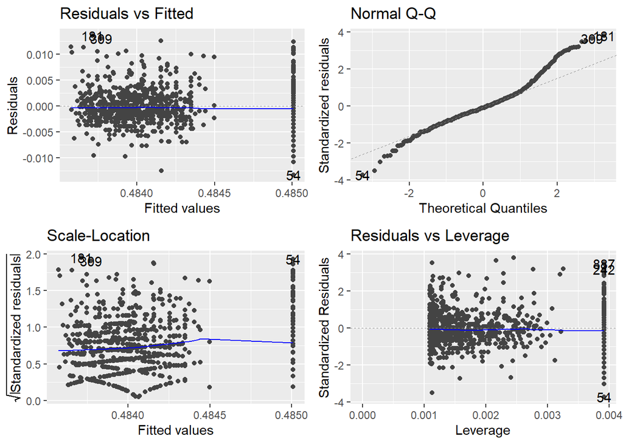

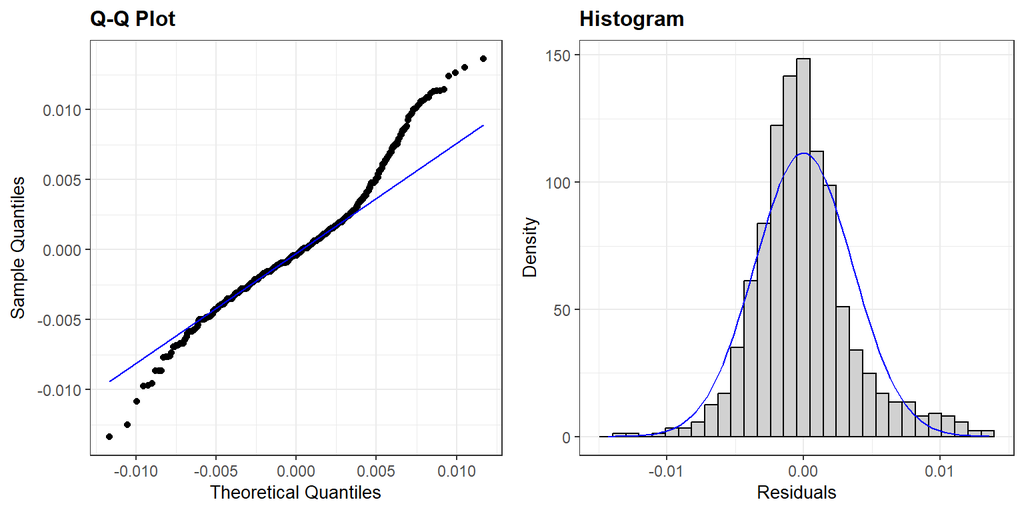

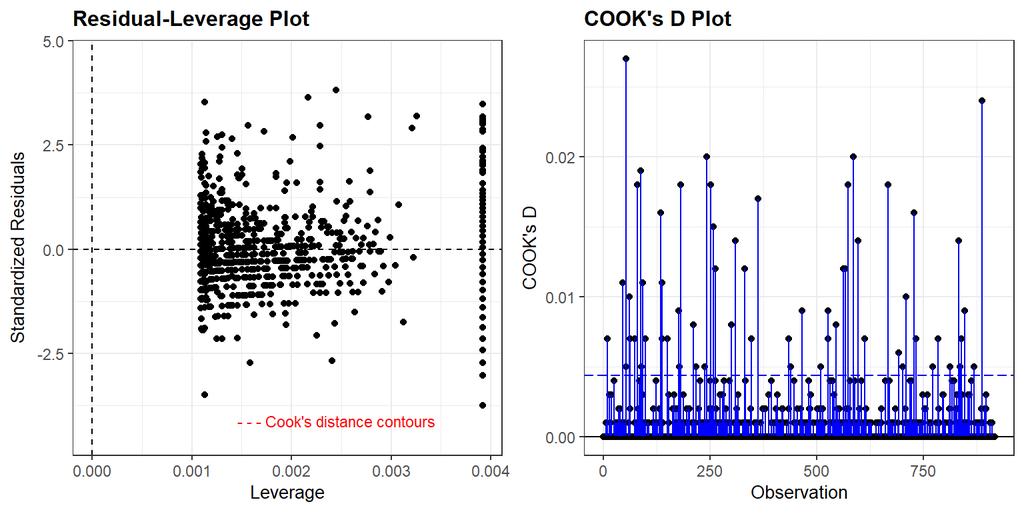

### **Интерпретация модели после преобразования переменных, без ковариат**

Добавление ковариат существенно улучшило объяснительную способность модели (R² вырос с 1.73% до 12.81%). Обе модели статистически значимы. Эффект физической активности сохраняется значимым даже после контроля на ковариаты. Более низкий RSE в модели с ковариатами указывает на лучшую точность предсказаний.

Физическая активность может быть связана с другими предикторами (например, люди с сопутствующими заболеваниями могут быть менее активны) При добавлении ковариат мы учитываем эти взаимосвязи, поэтому более низкая оценка эффекта в модели с ковариатами является более точной, так как учитывает влияние других факторов. Сохранение значимости эффекта говорит о том, что физическая активность имеет самостоятельное влияние на HbA1c, даже после учета других факторов.